# What is Data Mining

27/8/2018

## What is Data Mining?

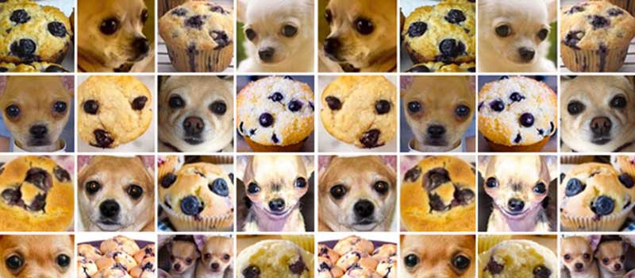

Chihuahua or Muffin?

## Definitions

“Data mining is the process of discovering patterns in large data sets involving methods at the intersection of machine learning, statistics, and database systems.”

“Machine learning (ML) is a field of artificial intelligence that uses statistical techniques to give computer systems the ability to”learn" (e.g., progressively improve performance on a specific task) from data, without being explicitly programmed."

*Wikipedia*

## Machine Learning vs Data Mining

- Still under debate, but…
- Data mining is carried out by a person, in a specific situation, on a particular data set, with a goal in mind.
- Machine learning on the other hand involves the study of algorithms that can extract information automatically (i.e., without on-line human guidance).

## More related terms

- Statistics
  - more theory-based. focused on testing hypotheses
- Machine learning
  - more heuristic, focused on building program that learns, more general than Data Mining
- Knowledge Discovery
  - integrates theory and heuristics
  - focus on the entire process of discovery, including data cleaning, learning, integration and visualization
- Data Mining
  - focus on the algorithms to extract patterns from data
- Distinctions are blurred!

## In this project

We will focus on both:

Apply data mining to explore the data in order to assess and improve it, and apply machine learning to obtain a good classifier.

## An example walk-through

In the next series of slides an entire analysis process is followed.  
It uses a fictitious case where loan application should be assessed.

If the chance is big of not getting your loan repaid, you obviously do not want to approve it!

## Example: credit assessment

*Given:* a loan application  
*Problem* (for the bank): should the bank approve the loan?  
*Data*: records from previous loans

## Load and inspect

## Load and inspect

```
##   customer salary age marital.status    sex default
## 1        1     25  44       divorced   male     yes
## 2        2     50  32        married female      no
## 3        3     47  38         single female      no
## 4        4     19  56       divorced   male     yes
## 5        5     31  61       divorced female      no
## 6        6     36  19         single female      no
```

## Visualize

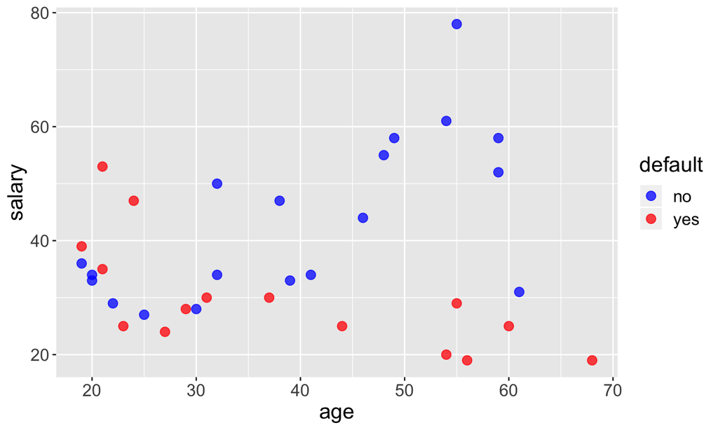

## Look for patterns

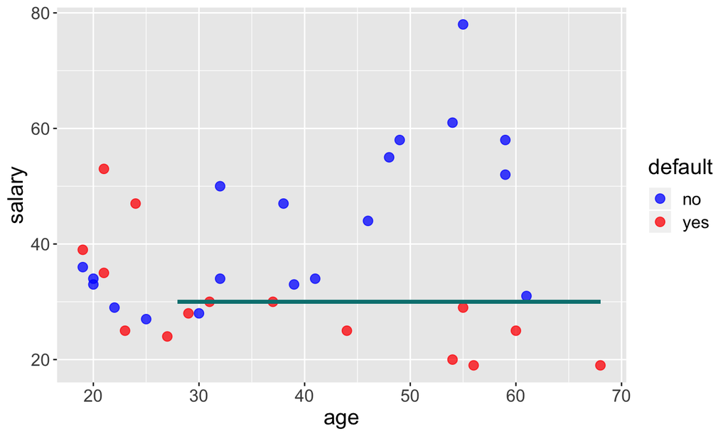

## Define rules

A first classification rule could be

```
 if income < 30 then default = true
else default = false
```

and this already performs pretty good

## Include more data: sex

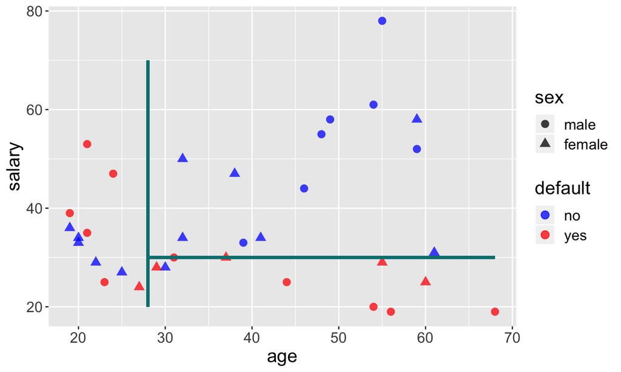

- Below age 28, sex is a excellent predictor of loan defection!

## Refine rules

```
 if income < 30 and age > 28 then default = true
if age < 28 and sex = m then default = true
else default = false
```

and now we have an almost perfect predictor

## The essence of Machine Learning

Find patterns in existing data to make predictions on new, unseen data.

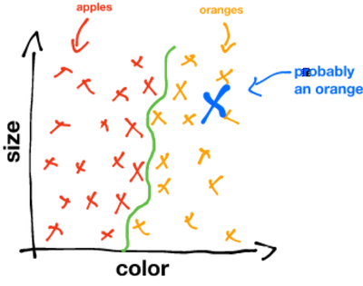

Apple or Orange?

## New loan applicants

Now two loan applicants appear at you bank:

- The first is a 56 year old female with an income of 49k$
- The other is a 27 year old male with an income of 26k$

Do you approve the loan?

**You get a 200$ commission for approved loans, but don’t get your 1000$ bonus for a defaulted loan**

## Visualize the new data

[figure not shown]

## Assessing the loan applicants

- The 56 year old female with an income of 49k$
  - Absolutely!
- The other is a 27 year old male with an income of 26k$
  - Not sure; need more input

## Explore other variables

There is one more variable: marital status.

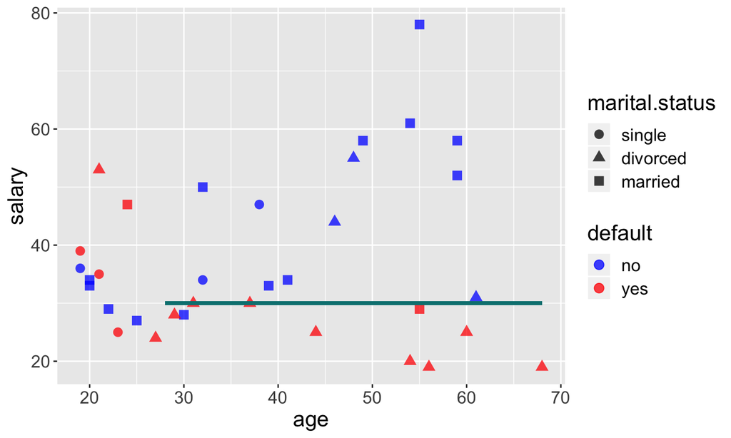

## A different view of the data

Sometimes a different data presentation is better

|  | single | divorced | married |
| --- | --- | --- | --- |
| no | 3 | 3 | 13 |
| yes | 3 | 10 | 2 |

Obviously, marital status is not randomly distributed!  
Marital status divorced means a much higher chance of loan defection

## Refine rules further

We could have arrived on something like this

```
 if income < 30 and age > 28
   then default = true
if age < 28 and sex = m
   then default = true
if age < 31 and status is not married
   then default = true
else default = false
```

## Enter machine learning

Let’s train a model using C4.5/J48

```r
library(RWeka)
fit <- J48(default ~ ., data=loans[, -1]) ##leave customer ID out
#ALTERNATIVE
#library(C50)
#fit <- C5.0(default ~ ., data=loans[, -1])
```

Yes, it is this simple….seemingly

## Have a look at the model

```
## J48 pruned tree
## ------------------
##
## salary <= 25: yes (7.0)
## salary > 25
## |   marital.status = single
## |   |   sex = male: yes (2.0)
## |   |   sex = female: no (3.0)
## |   marital.status = divorced
## |   |   age <= 41: yes (4.0)
## |   |   age > 41: no (3.0)
## |   marital.status = married: no (15.0/2.0)
##
## Number of Leaves  :  6
##
## Size of the tree :   10
```

## Investigate the performance

|  | predicted no | predicted yes |
| --- | --- | --- |
| actual no | 19 | 0 |
| actual yes | 2 | 13 |

An accuracy of 94%!

## And our two applicants

```r
print(newData)
```

```
##   salary age marital.status    sex
## 1     49  56        married female
## 2     26  27       divorced   male
```

```r
predict(fit, newData)
```

```
## [1] no  yes
## Levels: no yes
```

## Another example: Iris

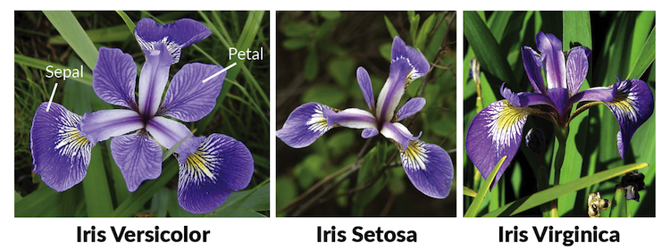

Three Iris species

## Two unknown Iris specimens

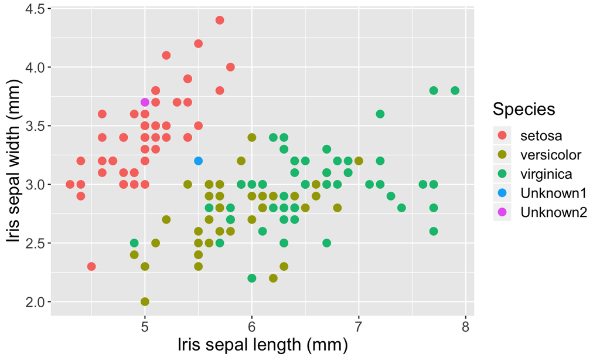

## Another dimension

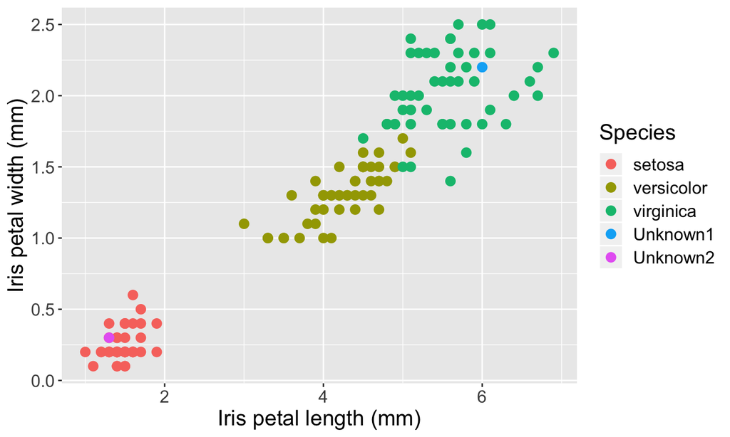

Looking from a different ‘angle’, Unknown 1 is obviously *virginica*!

## Summary

- You have seen the data mining process at work
- The goal is to classify new, unseen instances correctly based on what you have learned from previously collected data
- Different visualizations of your data are an essential part of good research